# Bird Detections

Brianna Saylor

2025-10-04

Point count surveys were completed across Tennessee looking for grassland birds. Surveyors examined which characteristics impacted the total number of birds detected at point counts. They measured environmental characteristics including litter depth, vegetation height, vegetation density, and percent cover of grass. Additionally, they measured the size of the site in ha and the start time of the survey (minutes after sunrise).

```r
summary.detections <- combined.detections %>%
  summarise(
  median = median(total_individuals),
  mean = mean(total_individuals),
  min = min(total_individuals),
  max = max(total_individuals))
kable(summary.detections, caption = "A summary kable dispaying the median, mean, minimum, and maximum number of detections at surveys.", digits = c(0, 2, 0, 0))
```

A summary kable dispaying the median, mean, minimum, and maximum number of detections at surveys.

| median | mean | min | max |
| --- | --- | --- | --- |
| 7 | 7.89 | 0 | 163 |

Will probably have some outliers in the data. Need to keep on eye out for this.

```r
glm.global <- glm(total_individuals ~ litter_avg + veg_ht_avg + vd_vo + pc_grass + site_ha + min_from_sunrise, family = poisson(link = "log"), data = combined.detections)
summary(glm.global)
```

```
##
## Call:
## glm(formula = total_individuals ~ litter_avg + veg_ht_avg + vd_vo +
##     pc_grass + site_ha + min_from_sunrise, family = poisson(link = "log"),
##     data = combined.detections)
##
## Coefficients:
##                    Estimate Std. Error z value Pr(>|z|)
## (Intercept)       2.3701619  0.0809845  29.267  < 2e-16 ***
## litter_avg        0.0314573  0.0118662   2.651  0.00803 **
## veg_ht_avg       -0.0032496  0.0014786  -2.198  0.02797 *
## vd_vo             0.0019937  0.0015833   1.259  0.20795
## pc_grass          0.0098337  0.0046899   2.097  0.03601 *
## site_ha          -0.0003578  0.0003780  -0.947  0.34387
## min_from_sunrise -0.0029974  0.0004384  -6.837 8.07e-12 ***
## ---
## Signif. codes:  0 '***' 0.001 '**' 0.01 '*' 0.05 '.' 0.1 ' ' 1
##
## (Dispersion parameter for poisson family taken to be 1)
##
##     Null deviance: 1318.8  on 190  degrees of freedom
## Residual deviance: 1241.1  on 184  degrees of freedom
## AIC: 1926.5
##
## Number of Fisher Scoring iterations: 6
```

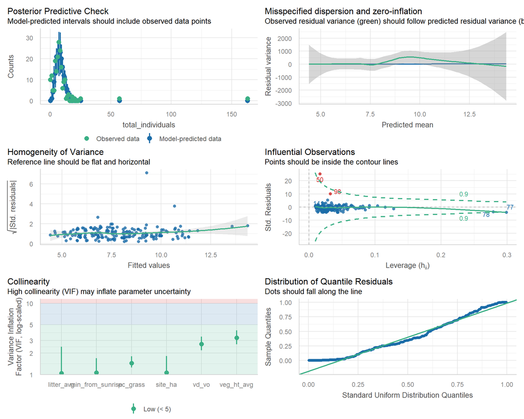

```r
library(easystats)
check_model(glm.global)
```

There are 2 outliers in the data which are much higher counts compared to the rest of the data. Let’s remove those.

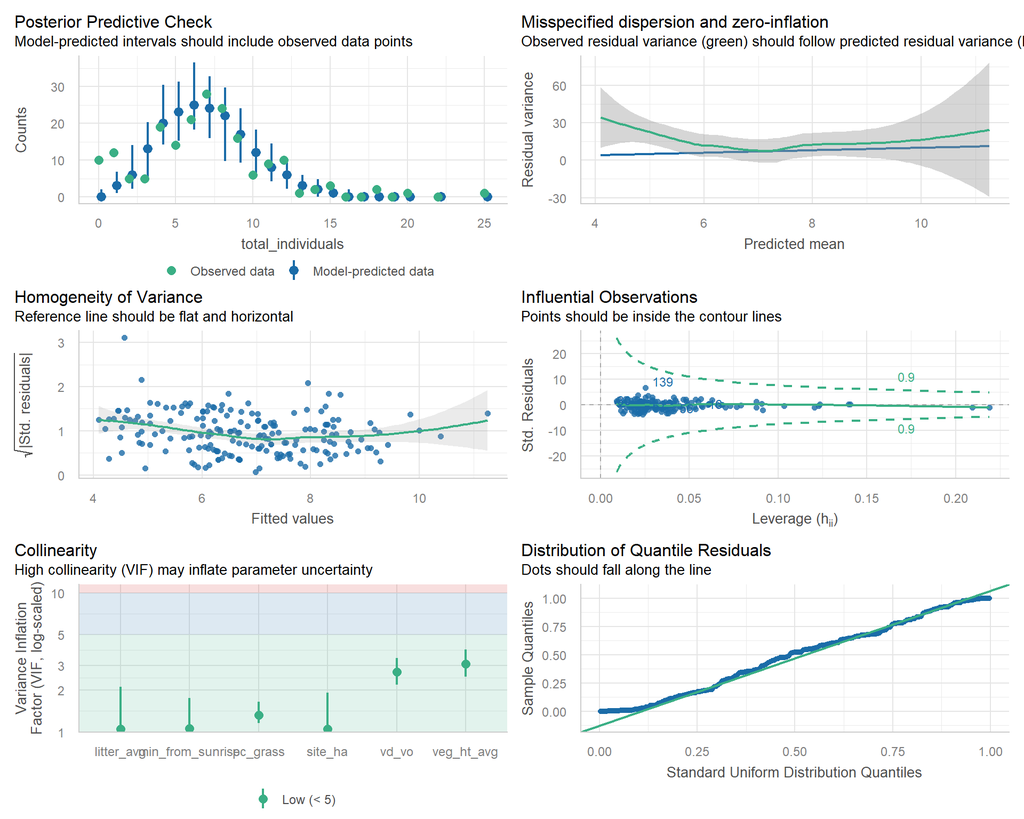

```r
check_model(glm.global.2)
```

We have a moderate amount of dispersion.

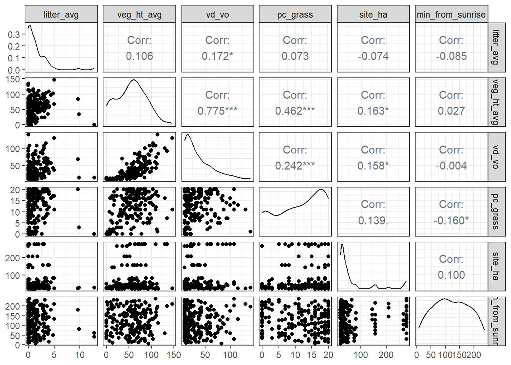

```r
# check for collinearity
library(GGally)
ggpairs(combined.detections, columns = c(2, 3, 4, 5, 6, 8)) + theme_bw()
```

Vegetation height and vegetation density appear to be highly correlated. Need to be careful of that in the models.

```r
# check for multicollinearity
library(performance)
performance::check_collinearity(glm.global.2)
```

```
## # Check for Multicollinearity
##
## Low Correlation
##
##              Term  VIF   VIF 95% CI adj. VIF Tolerance Tolerance 95% CI
##        litter_avg 1.05 [1.00, 2.10]     1.02      0.96     [0.48, 1.00]
##        veg_ht_avg 3.08 [2.49, 3.91]     1.76      0.32     [0.26, 0.40]
##             vd_vo 2.70 [2.19, 3.41]     1.64      0.37     [0.29, 0.46]
##          pc_grass 1.32 [1.16, 1.64]     1.15      0.76     [0.61, 0.86]
##           site_ha 1.05 [1.00, 1.91]     1.03      0.95     [0.52, 1.00]
##  min_from_sunrise 1.06 [1.00, 1.76]     1.03      0.94     [0.57, 1.00]
```

VIF values are <5 so we do not need to worry about multicollinearity.

```r
# display list of ranked models
model_comparison <- model.sel(models)
model_comparison
```

```
## Model selection table
##    (Int)   pc_grs veg_ht_avg     sit_ha min_frm_snr  ltt_avg    vd_vo df
## 5  1.786 0.014400                         -0.001663          0.004083  4
## 9  1.775 0.014320                         -0.001646 0.009368 0.003981  5
## 8  1.786 0.009952   0.004017 -2.007e-04   -0.001759                    5
## 12 1.764 0.011400   0.002275 -2.136e-04   -0.001696 0.009831 0.002243  7
## 10 1.964                                  -0.001903          0.004756  3
## 1  1.555 0.013260   0.003525                                           3
## 4  1.539 0.013010   0.003424                        0.017080           4
## 11 1.882 0.018270                         -0.001587                    3
## 7  1.554 0.013270   0.003516 -3.265e-04             0.015790           5
## 6  1.884 0.018370            -6.485e-05   -0.001576                    4
## 2  1.683 0.020700            -2.335e-04                                3
## 3  2.129                      1.652e-04   -0.001897                    3
##      logLik   AICc delta weight
## 5  -546.395 1101.0  0.00  0.503
## 9  -546.192 1102.7  1.70  0.214
## 8  -546.328 1103.0  1.98  0.187
## 12 -544.968 1104.6  3.55  0.085
## 10 -551.584 1109.3  8.29  0.008
## 1  -553.924 1114.0 12.97  0.001
## 4  -553.258 1114.7 13.72  0.001
## 11 -554.482 1115.1 14.09  0.000
## 7  -552.879 1116.1 15.08  0.000
## 6  -554.468 1117.2 16.15  0.000
## 2  -560.233 1126.6 25.59  0.000
## 3  -563.319 1132.8 31.76  0.000
## Models ranked by AICc(x)
```

```r
# select best supported models
subset(model_comparison, delta <5)
```

```
## Model selection table
##    (Int)   pc_grs veg_ht_avg     sit_ha min_frm_snr  ltt_avg    vd_vo df
## 5  1.786 0.014400                         -0.001663          0.004083  4
## 9  1.775 0.014320                         -0.001646 0.009368 0.003981  5
## 8  1.786 0.009952   0.004017 -0.0002007   -0.001759                    5
## 12 1.764 0.011400   0.002275 -0.0002136   -0.001696 0.009831 0.002243  7
##      logLik   AICc delta weight
## 5  -546.395 1101.0  0.00  0.508
## 9  -546.192 1102.7  1.70  0.217
## 8  -546.328 1103.0  1.98  0.189
## 12 -544.968 1104.6  3.55  0.086
## Models ranked by AICc(x)
```

Model 5, 9, and 8 all have delta AICc <2. Model 5 is 2.34 times more likely than model 9. (0.508/0.217=2.34) The global model does have a delta AICc <5.

```r
# calculate variable importance weights
MuMIn::sw(model_comparison)
```

```
##                      min_from_sunrise pc_grass vd_vo litter_avg veg_ht_avg
## Sum of weights:      1.00             0.99     0.81  0.30       0.27
## N containing models:    8               10        4     4          5
##                      site_ha
## Sum of weights:      0.27
## N containing models:    6
```

```r
# model averaging
model.avg <- model.avg(model_comparison, revised.var = TRUE)
model.avg
```

```
##
## Call:
## model.avg(object = model_comparison, revised.var = TRUE)
##
## Component models:
## '146'    '1456'   '1234'   '123456' '46'     '12'     '125'    '14'
## '1235'   '134'    '13'     '34'
##
## Coefficients:
##        (Intercept)       vd_vo   pc_grass min_from_sunrise  litter_avg
## full      1.782717 0.003135970 0.01318085     -0.001679270 0.002861623
## subset    1.782717 0.003868789 0.01328673     -0.001681899 0.009518861
##          veg_ht_avg       site_ha
## full   0.0009518711 -5.592074e-05
## subset 0.0034714627 -2.047905e-04
```

Now we can look at the direction of impact these variables have with the number of bird detections.

```r
summary(model.avg(model_comparison, subset = delta < 2))
```

```
##
## Call:
## model.avg(object = model_comparison, subset = delta < 2)
##
## Component model call:
## glm(formula = <3 unique values>, family = poisson(link = "log"), data =
##      combined.detections)
##
## Component models:
##      df  logLik    AICc delta weight
## 146   4 -546.40 1101.01  0.00   0.56
## 1456  5 -546.19 1102.71  1.70   0.24
## 1234  5 -546.33 1102.98  1.98   0.21
##
## Term codes:
##         pc_grass       veg_ht_avg          site_ha min_from_sunrise
##                1                2                3                4
##       litter_avg            vd_vo
##                5                6
##
## Model-averaged coefficients:
## (full average)
##                    Estimate Std. Error Adjusted SE z value Pr(>|z|)
## (Intercept)       1.783e+00  9.039e-02   9.099e-02  19.599  < 2e-16 ***
## vd_vo             3.213e-03  1.866e-03   1.869e-03   1.719 0.085562 .
## pc_grass          1.346e-02  4.922e-03   4.950e-03   2.720 0.006536 **
## min_from_sunrise -1.679e-03  4.647e-04   4.677e-04   3.589 0.000332 ***
## litter_avg        2.221e-03  8.133e-03   8.174e-03   0.272 0.785816
## veg_ht_avg        8.316e-04  1.688e-03   1.689e-03   0.492 0.622480
## site_ha          -4.156e-05  1.911e-04   1.921e-04   0.216 0.828719
##
## (conditional average)
##                    Estimate Std. Error Adjusted SE z value Pr(>|z|)
## (Intercept)       1.7832395  0.0903929   0.0909880  19.599  < 2e-16 ***
## vd_vo             0.0040524  0.0009962   0.0010028   4.041 5.32e-05 ***
## pc_grass          0.0134619  0.0049218   0.0049500   2.720 0.006536 **
## min_from_sunrise -0.0016787  0.0004647   0.0004677   3.589 0.000332 ***
## litter_avg        0.0093681  0.0145603   0.0146567   0.639 0.522716
## veg_ht_avg        0.0040170  0.0009867   0.0009932   4.044 5.25e-05 ***
## site_ha          -0.0002007  0.0003800   0.0003825   0.525 0.599694
## ---
## Signif. codes:  0 '***' 0.001 '**' 0.01 '*' 0.05 '.' 0.1 ' ' 1
```

```r
# calculating the exponentiated coefficients of our averaged model
exp(coef(model.avg))
```

```
##      (Intercept)            vd_vo         pc_grass min_from_sunrise
##        5.9459873        1.0038763        1.0133754        0.9983195
##       litter_avg       veg_ht_avg          site_ha
##        1.0095643        1.0034775        0.9997952
```

In conclusion, the factors that impact bird detections include survey start time, the percent cover of grass, and the vegetation density. To maximize detections surveys should be conducted closer to sunrise, in areas with large amounts of grass, and in areas with dense vegetation.